# Mathematical Methods for Artificial Intelligence Lab 2

Vytautas Kraujalis

2021-10-03

# 1 Reading Data

```r
set.seed(123)

data <- read.csv("water_potability.csv")
```

# 2 Required packages

```r
library(SmartEDA)
library(dplyr)
library(ggplot2)
library(mice)
library(VIM)
library(glmnet)
library(caret)
library(ROCR)

# Function for binary class accuracy from confusion matrix
classAcc <- function(confusionMatrix) {
  class0 <- round(confusionMatrix$table[1, 1] / sum(confusionMatrix$table[, 1]) * 100, 1)
  class1 <- round(confusionMatrix$table[2, 2] / sum(confusionMatrix$table[, 2]) * 100, 1)
  acc <- c(class0, class1)
  names(acc) <- c("Acc: 0", "Acc: 1")
  return(acc)
}
```

# 3 EDA, first look at the dataset

```r
ExpData(data, type = 1)
```

```
##                                           Descriptions   Value
## 1                                   Sample size (nrow)    3276
## 2                              No. of variables (ncol)      10
## 3                    No. of numeric/interger variables      10
## 4                              No. of factor variables       0
## 5                                No. of text variables       0
## 6                             No. of logical variables       0
## 7                          No. of identifier variables       6
## 8                                No. of date variables       0
## 9             No. of zero variance variables (uniform)       0
## 10               %. of variables having complete cases 70% (7)
## 11   %. of variables having >0% and <50% missing cases 30% (3)
## 12 %. of variables having >=50% and <90% missing cases  0% (0)
## 13          %. of variables having >=90% missing cases  0% (0)
```

We can see, that we have 10 numerical variables and 3276 observations, we can also notice, that 3 variables have missing variables.

```r
summary(data)
```

```
##        ph            Hardness          Solids         Chloramines
##  Min.   : 0.000   Min.   : 47.43   Min.   :  320.9   Min.   : 0.352
##  1st Qu.: 6.093   1st Qu.:176.85   1st Qu.:15666.7   1st Qu.: 6.127
##  Median : 7.037   Median :196.97   Median :20927.8   Median : 7.130
##  Mean   : 7.081   Mean   :196.37   Mean   :22014.1   Mean   : 7.122
##  3rd Qu.: 8.062   3rd Qu.:216.67   3rd Qu.:27332.8   3rd Qu.: 8.115
##  Max.   :14.000   Max.   :323.12   Max.   :61227.2   Max.   :13.127
##  NA's   :491
##     Sulfate       Conductivity   Organic_carbon  Trihalomethanes
##  Min.   :129.0   Min.   :181.5   Min.   : 2.20   Min.   :  0.738
##  1st Qu.:307.7   1st Qu.:365.7   1st Qu.:12.07   1st Qu.: 55.845
##  Median :333.1   Median :421.9   Median :14.22   Median : 66.622
##  Mean   :333.8   Mean   :426.2   Mean   :14.28   Mean   : 66.396
##  3rd Qu.:360.0   3rd Qu.:481.8   3rd Qu.:16.56   3rd Qu.: 77.337
##  Max.   :481.0   Max.   :753.3   Max.   :28.30   Max.   :124.000
##  NA's   :781                                     NA's   :162
##    Turbidity       Potability
##  Min.   :1.450   Min.   :0.0000
##  1st Qu.:3.440   1st Qu.:0.0000
##  Median :3.955   Median :0.0000
##  Mean   :3.967   Mean   :0.3901
##  3rd Qu.:4.500   3rd Qu.:1.0000
##  Max.   :6.739   Max.   :1.0000
##
```

Variables “ph”, “Sulfate” and “Trihalomethanes” have missing values.

Let’s look how our missing values are distributed:

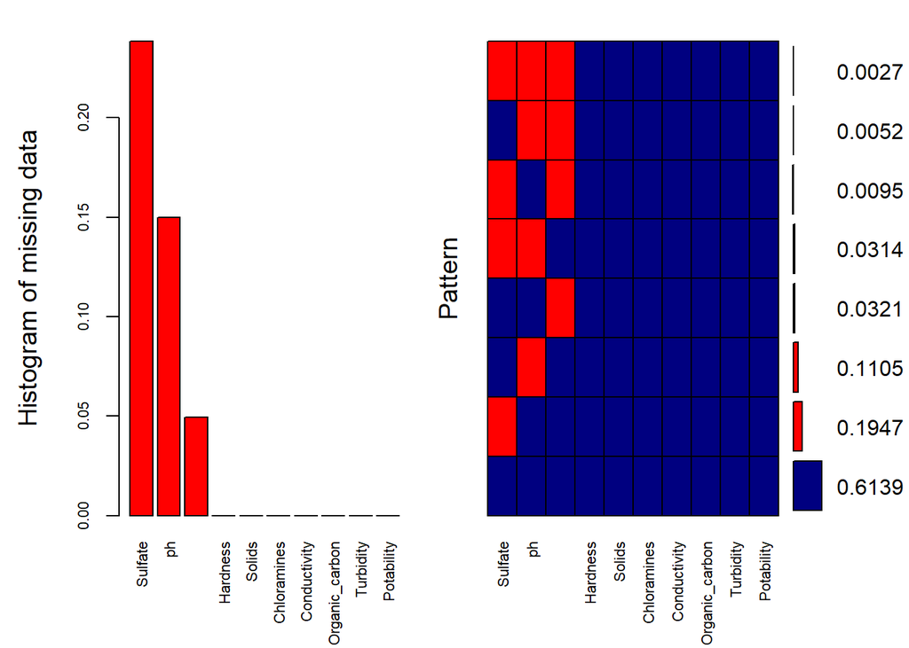

```
##
##  Variables sorted by number of missings:
##         Variable      Count
##          Sulfate 0.23840049
##               ph 0.14987790
##  Trihalomethanes 0.04945055
##         Hardness 0.00000000
##           Solids 0.00000000
##      Chloramines 0.00000000
##     Conductivity 0.00000000
##   Organic_carbon 0.00000000
##        Turbidity 0.00000000
##       Potability 0.00000000
```

```r
aggr(data, col = c("navyblue", "red"), numbers = TRUE, sortVars = TRUE, labels = names(data), cex.axis = .7, gap = 3, ylab = c("Histogram of missing data", "Pattern"))
```

We are going to use “mice” package for missing values imputation.

```r
imp <- mice(data)
summary(imp)
```

```
## Class: mids
## Number of multiple imputations:  5
## Imputation methods:
##              ph        Hardness          Solids     Chloramines         Sulfate
##           "pmm"              ""              ""              ""           "pmm"
##    Conductivity  Organic_carbon Trihalomethanes       Turbidity      Potability
##              ""              ""           "pmm"              ""              ""
## PredictorMatrix:
##              ph Hardness Solids Chloramines Sulfate Conductivity Organic_carbon
## ph            0        1      1           1       1            1              1
## Hardness      1        0      1           1       1            1              1
## Solids        1        1      0           1       1            1              1
## Chloramines   1        1      1           0       1            1              1
## Sulfate       1        1      1           1       0            1              1
## Conductivity  1        1      1           1       1            0              1
##              Trihalomethanes Turbidity Potability
## ph                         1         1          1
## Hardness                   1         1          1
## Solids                     1         1          1
## Chloramines                1         1          1
## Sulfate                    1         1          1
## Conductivity               1         1          1
```

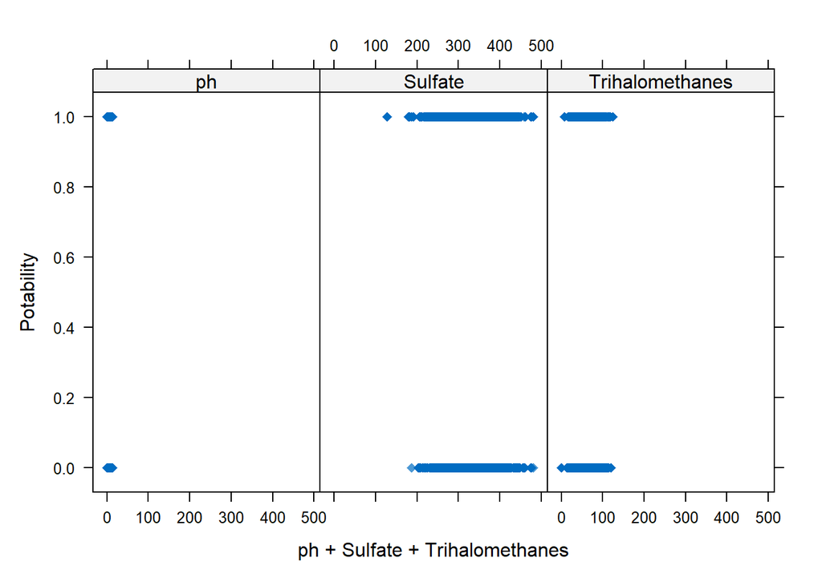

```r
data_noMissing <- complete(imp, 1)

xyplot(imp, Potability ~ ph + Sulfate + Trihalomethanes, pch = 18, cex = 1)
```

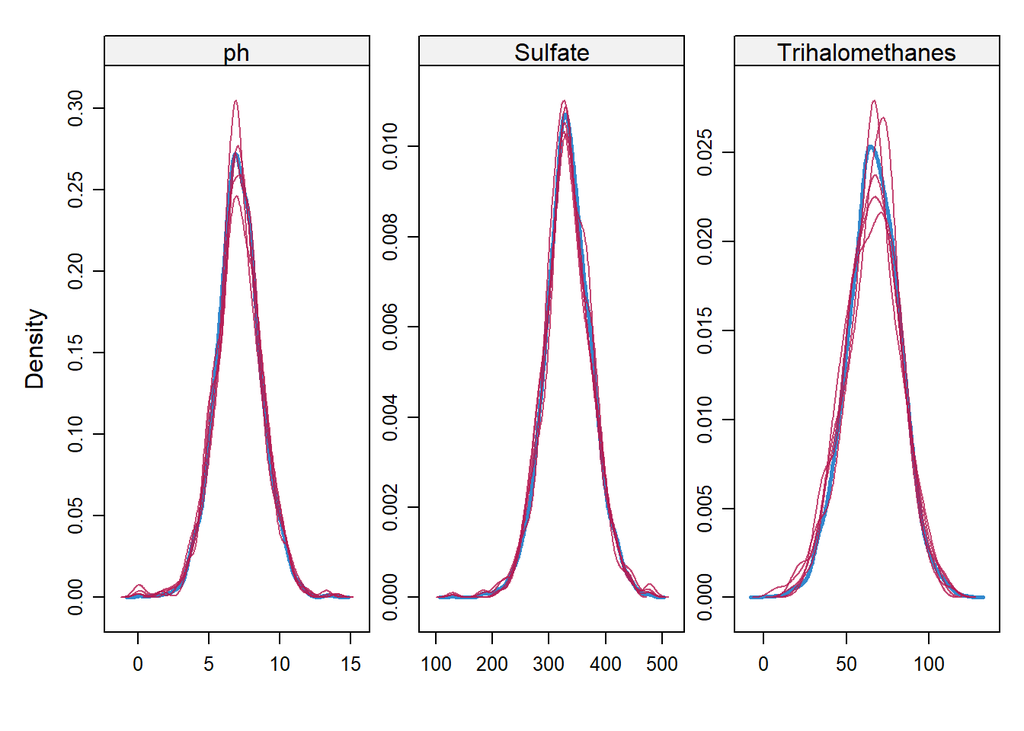

```r
densityplot(imp)
```

The scatter plot of imputed data (red) and observed values (blue) shows that we did not produced any outliers. Density plots also shows no bad variation of imputed data.

# 4 Pre-process

## 4.1 Data split

```r
indices <- createDataPartition(data_noMissing$Potability, p = 0.8, list = FALSE)
train <- data_noMissing[indices, ]
test <- data_noMissing[-indices, ]

label_index <- which(colnames(train) == "Potability")
```

Splitted a dataset by 80% / 20% rule. Created a training dataset with 2621 (80.006105%) observations and testing dataset with 655 (19.993895%) observations.

## 4.2 Data transformation

```r
preProcValues <- preProcess(train[, -label_index], method = c("center", "scale"))
train[, -label_index] <- predict(preProcValues, train[, -label_index])
test[, -label_index] <- predict(preProcValues, test[, -label_index])
```

We also centered and scaled our data. We transformed the testing dataset based on the pre process of training dataset.

# 5 Logistic Regression

## 5.1 Simple Logistic Regression

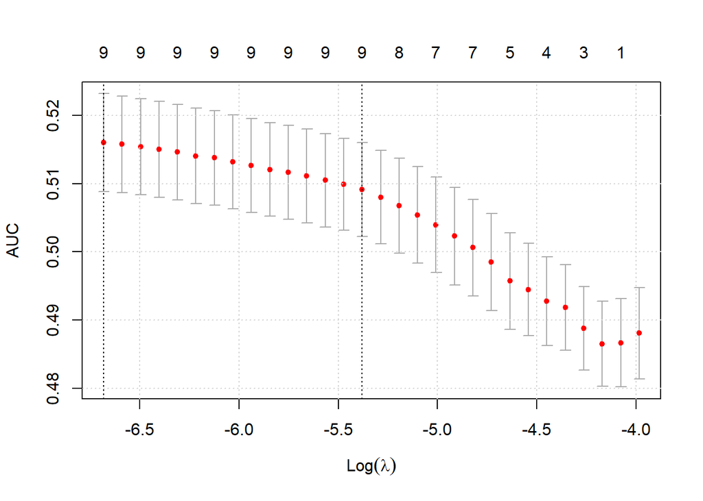

```r
fit_glm_cv <- cv.glmnet(as.matrix(train[, -label_index]), train[, label_index], family = "binomial", type.measure = "auc", keep = T, nfolds = 10)
plot(fit_glm_cv)
grid()
```

Best lambda:

```r
fit_glm_cv$lambda.min
```

```
## [1] 0.001252873
```

At first glance, our model on the training set does not perform well. Let’s take the best result and run a logistic regression again

Using fitted logistic regression model on the testing dataset:

```r
fit_glm <- glmnet(as.matrix(train[, -label_index]), train[, label_index], family = "binomial", lambda = fit_glm_cv$lambda.min)
test_glm <- predict(fit_glm, as.matrix(test[, -label_index]), type = "class")
confusionMatrix <- confusionMatrix(as.factor(test_glm), as.factor(test$Potability), mode = "everything")
print(confusionMatrix)
```

```
## Confusion Matrix and Statistics
##
##           Reference
## Prediction   0   1
##          0 411 243
##          1   1   0
##
##                Accuracy : 0.6275
##                  95% CI : (0.5892, 0.6646)
##     No Information Rate : 0.629
##     P-Value [Acc > NIR] : 0.5496
##
##                   Kappa : -0.0031
##
##  Mcnemar's Test P-Value : <2e-16
##
##             Sensitivity : 0.9976
##             Specificity : 0.0000
##          Pos Pred Value : 0.6284
##          Neg Pred Value : 0.0000
##               Precision : 0.6284
##                  Recall : 0.9976
##                      F1 : 0.7711
##              Prevalence : 0.6290
##          Detection Rate : 0.6275
##    Detection Prevalence : 0.9985
##       Balanced Accuracy : 0.4988
##
##        'Positive' Class : 0
##
```

```r
print(classAcc(confusionMatrix))
```

```
## Acc: 0 Acc: 1
##   99.8    0.0
```

The overall accuracy is 63%, but the No Information Rate is 0.63. We can see from the confusion table and from the NIR, that our model poorly predicts one class. Class “1” has 0% accuracy

Let’s check the ROC curves:

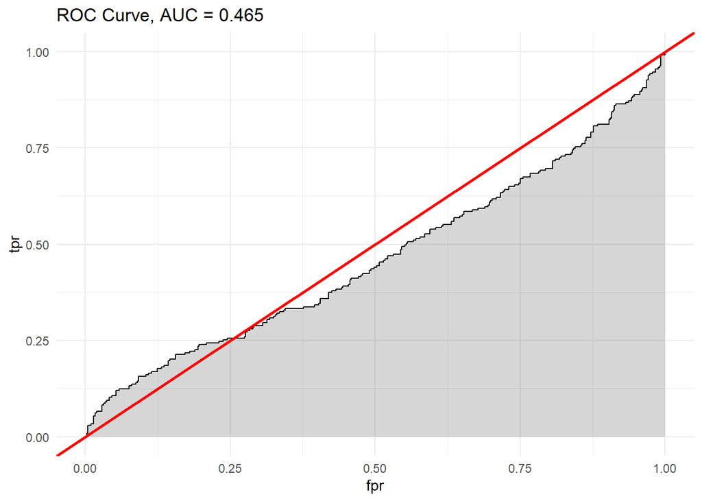

```r
prob_glm <- predict(fit_glm, as.matrix(test[, -label_index]), type = "response", s = fit_glm$lambda)
pred_glm <- prediction(prob_glm, test[, label_index])
perf_glm <- performance(pred_glm, measure = "tpr", x.measure = "fpr")

# area under the curve
auc <- attr(performance(pred_glm, "auc"), "y.values")[[1]]
auc <- round(auc, digits = 3)

roc_glm <- data.frame(fpr = attr(perf_glm, "x.values")[[1]], tpr = attr(perf_glm, "y.values")[[1]])

ggplot(roc_glm, aes(x = fpr, ymin = 0, ymax = tpr)) +
  geom_ribbon(alpha = 0.2) +
  geom_line(aes(y = tpr)) +
  ggtitle(paste0("ROC Curve, AUC = ", auc)) +
  geom_abline(slope = 1, color = "red", size = 1) +
  theme_minimal()
```

The AUC is 0.465, so our model is even worse than a random guess.

## 5.2 Logistic Regression with interactions

Let’s try to add interactions between variables to see if that could lead to a better prediction.

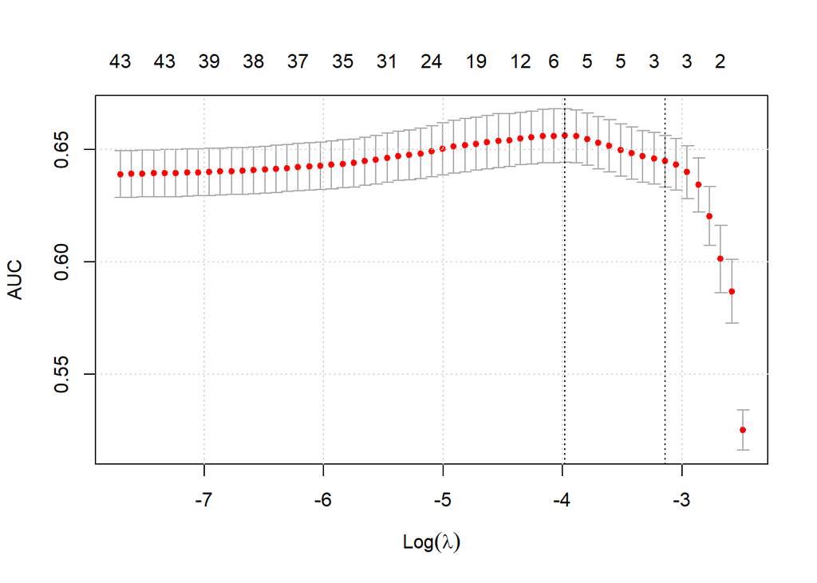

```r
formula <- as.formula(" ~ .^2")

# We add interactions of our primary variables
train_int <- model.matrix(formula, data = train[, -label_index])
train_int <- train_int[, 2:ncol(train_int)] %>%
  bind_cols(Potability = train$Potability) %>%
  as.matrix()
train_int_label_index <- which(colnames(train_int) == "Potability")

test_int <- model.matrix(formula, data = test[, -label_index])
test_int <- test_int[, 2:ncol(test_int)] %>%
  bind_cols(Potability = test$Potability) %>%
  as.matrix()

fit_glm_cv_int <- cv.glmnet(train_int[, -train_int_label_index], train_int[, train_int_label_index], family = "binomial", type.measure = "auc", keep = T, nfolds = 10)
plot(fit_glm_cv_int)
grid()
```

Best lambda:

```r
fit_glm_cv_int$lambda.min
```

```
## [1] 0.01869524
```

The addition of interactions seems to give a better result, let’s try the fitted model on a test dataset:

```r
fit_glm_int <- glmnet(train_int[, -train_int_label_index], train_int[, train_int_label_index], family = "binomial", lambda = fit_glm_cv_int$lambda.min)
test_glm_int <- predict(fit_glm_int, test_int[, -train_int_label_index], type = "class")
confusionMatrix <- confusionMatrix(as.factor(test_glm_int), as.factor(test_int[, train_int_label_index]), mode = "everything")
print(confusionMatrix)
```

```
## Confusion Matrix and Statistics
##
##           Reference
## Prediction   0   1
##          0 400 199
##          1  12  44
##
##                Accuracy : 0.6779
##                  95% CI : (0.6406, 0.7135)
##     No Information Rate : 0.629
##     P-Value [Acc > NIR] : 0.005094
##
##                   Kappa : 0.1804
##
##  Mcnemar's Test P-Value : < 2.2e-16
##
##             Sensitivity : 0.9709
##             Specificity : 0.1811
##          Pos Pred Value : 0.6678
##          Neg Pred Value : 0.7857
##               Precision : 0.6678
##                  Recall : 0.9709
##                      F1 : 0.7913
##              Prevalence : 0.6290
##          Detection Rate : 0.6107
##    Detection Prevalence : 0.9145
##       Balanced Accuracy : 0.5760
##
##        'Positive' Class : 0
##
```

```r
print(classAcc(confusionMatrix))
```

```
## Acc: 0 Acc: 1
##   97.1   18.1
```

The overall accuracy is 68%, but now, the addition of interactions between variables led to 18% accuracy of the “1” class, while the accuracy for class “0” only dropped to 97%.

Let’s check the ROC curves:

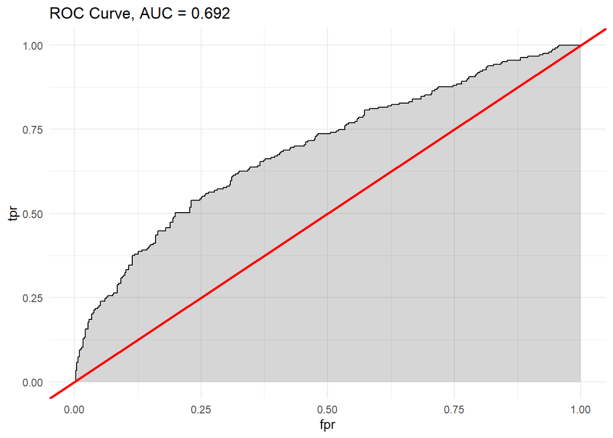

```r
prob_glm_int <- predict(fit_glm_int, test_int[, -train_int_label_index], type = "response", s = fit_glm_int$lambda)
pred_glm_int <- prediction(prob_glm_int, test_int[, train_int_label_index])
perf_glm_int <- performance(pred_glm_int, measure = "tpr", x.measure = "fpr")

# area under the curve
auc <- attr(performance(pred_glm_int, "auc"), "y.values")[[1]]
auc <- round(auc, digits = 3)

roc_glm_int <- data.frame(fpr = attr(perf_glm_int, "x.values")[[1]], tpr = attr(perf_glm_int, "y.values")[[1]])

ggplot(roc_glm_int, aes(x = fpr, ymin = 0, ymax = tpr)) +
  geom_ribbon(alpha = 0.2) +
  geom_line(aes(y = tpr)) +
  ggtitle(paste0("ROC Curve, AUC = ", auc)) +
  geom_abline(slope = 1, color = "red", size = 1) +
  theme_minimal()
```

This time, the AUC is 0.692 and our model looks better than a random guess.

## 5.3 Logistic Regression with interactions and 2nd order polynomials

Interactions seemed to help in prediction, now let’s try to add 2nd order polynomials of variables.

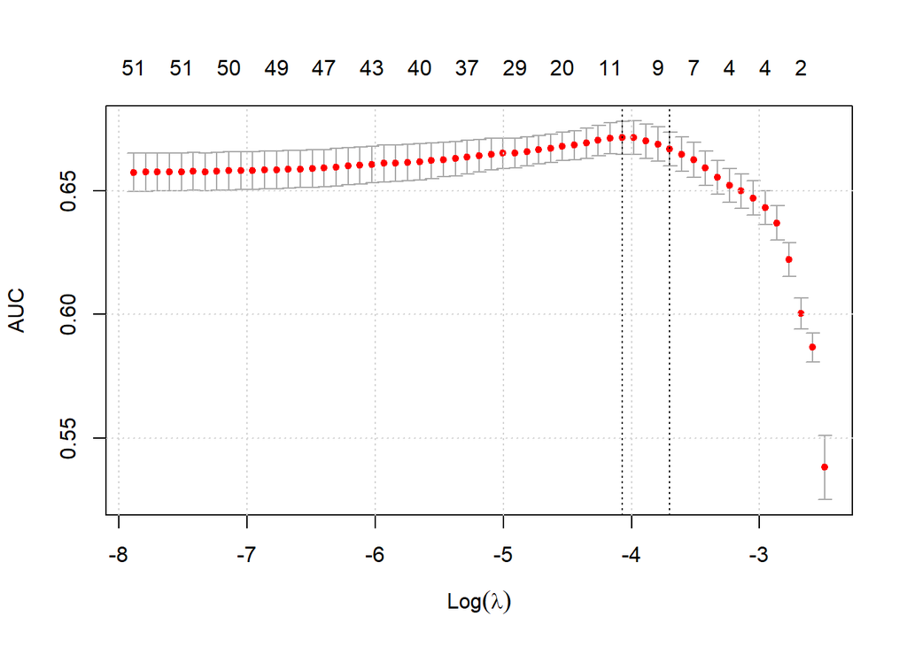

```r
formula <- as.formula(paste(" ~ .^2 + ", paste("poly(", colnames(train[, -label_index]), ",2, raw=TRUE)[, 2]", collapse = " + ")))

# We add interactions of our primary variables
train_int_pol2 <- model.matrix(formula, data = train[, -label_index])
train_int_pol2 <- train_int_pol2[, 2:ncol(train_int_pol2)] %>%
  bind_cols(Potability = train$Potability) %>%
  as.matrix()
train_int_pol2_label_index <- which(colnames(train_int_pol2) == "Potability")

test_int_pol2 <- model.matrix(formula, data = test[, -label_index])
test_int_pol2 <- test_int_pol2[, 2:ncol(test_int_pol2)] %>%
  bind_cols(Potability = test$Potability) %>%
  as.matrix()

fit_glm_cv_int_pol2 <- cv.glmnet(train_int_pol2[, -train_int_pol2_label_index], train_int_pol2[, train_int_pol2_label_index], family = "binomial", type.measure = "auc", keep = T, nfolds = 10)
plot(fit_glm_cv_int_pol2)
grid()
```

Best lambda:

```r
fit_glm_cv_int_pol2$lambda.min
```

```
## [1] 0.01703441
```

The addition of interactions and 2nd order polynomials seems to give a slightly better result than just with interactions, let’s try the fitted model on a test dataset:

```r
fit_glm_int_pol2 <- glmnet(train_int_pol2[, -train_int_pol2_label_index], train_int_pol2[, train_int_pol2_label_index], family = "binomial", lambda = fit_glm_cv_int_pol2$lambda.min)
test_glm_int_pol2 <- predict(fit_glm_int_pol2, test_int_pol2[, -train_int_pol2_label_index], type = "class")
confusionMatrix <- confusionMatrix(as.factor(test_glm_int_pol2), as.factor(test_int_pol2[, train_int_pol2_label_index]), mode = "everything")
print(confusionMatrix)
```

```
## Confusion Matrix and Statistics
##
##           Reference
## Prediction   0   1
##          0 397 189
##          1  15  54
##
##                Accuracy : 0.6885
##                  95% CI : (0.6515, 0.7239)
##     No Information Rate : 0.629
##     P-Value [Acc > NIR] : 0.0008193
##
##                   Kappa : 0.2178
##
##  Mcnemar's Test P-Value : < 2.2e-16
##
##             Sensitivity : 0.9636
##             Specificity : 0.2222
##          Pos Pred Value : 0.6775
##          Neg Pred Value : 0.7826
##               Precision : 0.6775
##                  Recall : 0.9636
##                      F1 : 0.7956
##              Prevalence : 0.6290
##          Detection Rate : 0.6061
##    Detection Prevalence : 0.8947
##       Balanced Accuracy : 0.5929
##
##        'Positive' Class : 0
##
```

```r
print(classAcc(confusionMatrix))
```

```
## Acc: 0 Acc: 1
##   96.4   22.2
```

Let’s check the ROC curves:

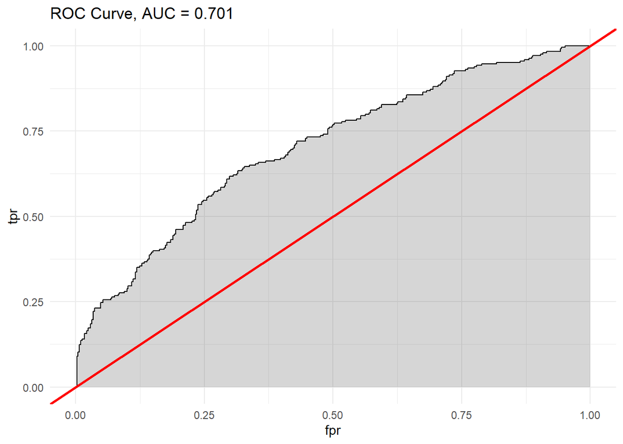

```r
prob_glm_int_pol2 <- predict(fit_glm_int_pol2, test_int_pol2[, -train_int_pol2_label_index], type = "response", s = fit_glm_int_pol2$lambda)
pred_glm_int_pol2 <- prediction(prob_glm_int_pol2, test_int_pol2[, train_int_pol2_label_index])
perf_glm_int_pol2 <- performance(pred_glm_int_pol2, measure = "tpr", x.measure = "fpr")

# area under the curve
auc <- attr(performance(pred_glm_int_pol2, "auc"), "y.values")[[1]]
auc <- round(auc, digits = 3)

roc_glm_int_pol2 <- data.frame(fpr = attr(perf_glm_int_pol2, "x.values")[[1]], tpr = attr(perf_glm_int_pol2, "y.values")[[1]])

ggplot(roc_glm_int_pol2, aes(x = fpr, ymin = 0, ymax = tpr)) +
  geom_ribbon(alpha = 0.2) +
  geom_line(aes(y = tpr)) +
  ggtitle(paste0("ROC Curve, AUC = ", auc)) +
  geom_abline(slope = 1, color = "red", size = 1) +
  theme_minimal()
```

This time, the AUC increased to 0.7. Overall, just a small increase after the interactions.

# 6 Conclusion

A logistic regression with interactions between variables and 2nd order polynomials seemed to give the best prediction. Addition of 2nd order polynomial just slightly increased the AUC and accuracy, so there’s no need to try the next order.

Best lambda, obtained from the cross-validation, is 0.017. The overall accuracy on a test dataset is 69%, while the accurcy for “0” class is 96.4% and for class “1” is 22.2%.

The AUC is 0.701